# PS0002 Lab 8 Notes

Caleb Tay (caleb.tay@ntu.edu.sg)

14 Mar 2025

# Note on Lab 8

This lab solution only involves the use of the code taught in the tutorial, i.e. with the `knn()` function from `class`. Again, I would emphasise and encourage you to use the `train()` function from `caret`, which is much more robust in the training process. It also simplifies your training process.

Again, take note on the use of the `preProcess` parameter in the `train()` function, if you have already normalised your data.

# Exploring and preparing the dataset

The data is stored in a `.csv` file, which we read in. We can see that there are 400 observations of 4 variables, and `admit` is our outcome variable of interest. The scales of all the features are also extremely different.

```r
grad <- read.csv('gradadmit.csv', header=T)
str(grad)
```

```
## 'data.frame':    400 obs. of  4 variables:
##  $ admit: int  0 1 1 1 0 1 1 0 1 0 ...
##  $ gre  : int  380 660 800 640 520 760 560 400 540 700 ...
##  $ gpa  : num  3.61 3.67 4 3.19 2.93 3 2.98 3.08 3.39 3.92 ...
##  $ rank : int  3 3 1 4 4 2 1 2 3 2 ...
```

```r
summary(grad)
```

```
##      admit             gre             gpa             rank
##  Min.   :0.0000   Min.   :220.0   Min.   :2.260   Min.   :1.000
##  1st Qu.:0.0000   1st Qu.:520.0   1st Qu.:3.130   1st Qu.:2.000
##  Median :0.0000   Median :580.0   Median :3.395   Median :2.000
##  Mean   :0.3175   Mean   :587.7   Mean   :3.390   Mean   :2.485
##  3rd Qu.:1.0000   3rd Qu.:660.0   3rd Qu.:3.670   3rd Qu.:3.000
##  Max.   :1.0000   Max.   :800.0   Max.   :4.000   Max.   :4.000
```

We convert `admit` into a factor and perform a min-max normalisation on the predictors.

```r
grad$admit <- factor(grad$admit)

nor <- function(x) { (x - min(x)) / (max(x) - min(x)) }
grad.nor <- grad
grad.nor[2:4] <- sapply(grad.nor[2:4], nor)
str(grad.nor)
```

```
## 'data.frame':    400 obs. of  4 variables:
##  $ admit: Factor w/ 2 levels "0","1": 1 2 2 2 1 2 2 1 2 1 ...
##  $ gre  : num  0.276 0.759 1 0.724 0.517 ...
##  $ gpa  : num  0.776 0.81 1 0.534 0.385 ...
##  $ rank : num  0.667 0.667 0 1 1 ...
```

# Training and evaluating the model

To train the model, we split the data into a training and test dataset as usual. In this case, the data is split into the predictors (`train.x` and `test.x`) and the outcome (`train.y` and `test.y`) for easier input into `knn()`. We see that the $k=1$ achieves the best accuracy.

```r
set.seed(100)
train.idx <- sample(nrow(grad.nor), nrow(grad.nor)*0.8)
train.x <- grad.nor[train.idx, 2:4]
train.y <- grad.nor[train.idx, 1]
test.x <- grad.nor[-train.idx, 2:4]
test.y <- grad.nor[-train.idx, 1]

library(class)
accuracy <- rep(0, 30)
for (i in 1:30) {
  set.seed(101)
  knn.i <- knn(train.x, test.x, cl=train.y, k=i)
  accuracy[i] <- mean(knn.i == test.y)
  cat("k =", i, "accuracy =", accuracy[i], "\n")
}
```

```
## k = 1 accuracy = 0.725
## k = 2 accuracy = 0.6625
## k = 3 accuracy = 0.675
## k = 4 accuracy = 0.625
## k = 5 accuracy = 0.6875
## k = 6 accuracy = 0.6625
## k = 7 accuracy = 0.6875
## k = 8 accuracy = 0.6875
## k = 9 accuracy = 0.6875
## k = 10 accuracy = 0.6875
## k = 11 accuracy = 0.675
## k = 12 accuracy = 0.6875
## k = 13 accuracy = 0.6875
## k = 14 accuracy = 0.6875
## k = 15 accuracy = 0.6625
## k = 16 accuracy = 0.6625
## k = 17 accuracy = 0.675
## k = 18 accuracy = 0.6625
## k = 19 accuracy = 0.675
## k = 20 accuracy = 0.6625
## k = 21 accuracy = 0.675
## k = 22 accuracy = 0.6875
## k = 23 accuracy = 0.6875
## k = 24 accuracy = 0.6875
## k = 25 accuracy = 0.7
## k = 26 accuracy = 0.7
## k = 27 accuracy = 0.675
## k = 28 accuracy = 0.675
## k = 29 accuracy = 0.6625
## k = 30 accuracy = 0.6625
```

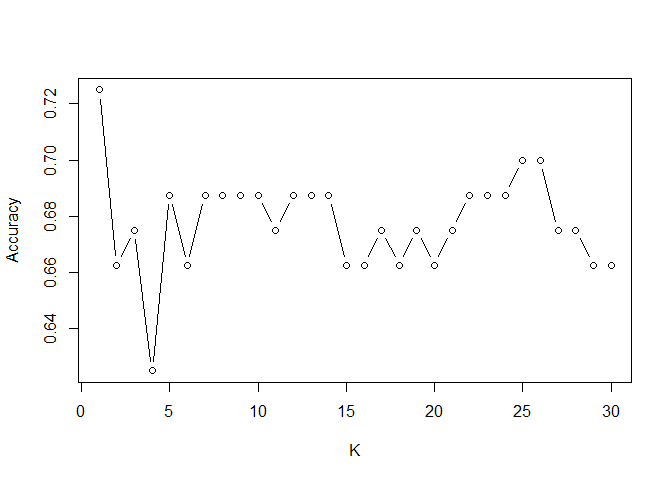

```r
plot(accuracy, type="b", xlab="K", ylab="Accuracy")
```

```r
which.max(accuracy)
```

```
## [1] 1
```

Evaluating this model with the confusion matrix, we see this kNN model has an accuracy of 72.5%, a false negative rate of 40% (10/25), and a false positive rate of 21.8% (12/55).

```r
set.seed(101)
yhat.knn <- knn(train.x, test.x, cl=train.y, k=1)
mean(yhat.knn == test.y)
```

```
## [1] 0.725
```

```r
table(predicted=yhat.knn, observed=test.y)
```

```
##          observed
## predicted  0  1
##         0 43 10
##         1 12 15
```

# Logistic regression model

We train and evaluate a logistic regression model on the same data. Since `train.x` and `test.x` do not contain the outcome variable `admit` (from how I split the data earlier), they have to be added back. You may also recreate the datasets, indexing the dataset with `train.idx`.

```r
train.data <- cbind(train.x, admit=train.y)
test.data <- cbind(test.x, admit=test.y)
```

The training of the model goes as usual. Note that the interpretation of the coefficients is extremely different, as the training and test data we used was scaled. A unit change now represents the entire range of values of one predictor. For example, a unit change in `gre` takes us from 0 to 1, which corresponds to an unscaled `gre` of 220 to 800. This scaling in the predictors, however, does not affect our final results.

The logistic model achieves an accuracy of 68.8%, a false negative rate of 76%, and a false positive rate of 10.9%. How can you bring down this false negative rate? Will there be any trade-offs?

```r
m.logistic <- glm(admit ~ ., train.data, family="binomial")
summary(m.logistic)
```

```
##
## Call:
## glm(formula = admit ~ ., family = "binomial", data = train.data)
##
## Coefficients:
##             Estimate Std. Error z value Pr(>|z|)
## (Intercept)  -1.5737     0.5603  -2.808  0.00498 **
## gre           1.0851     0.7108   1.526  0.12689
## gpa           1.4679     0.6252   2.348  0.01888 *
## rank         -1.8531     0.4320  -4.289 1.79e-05 ***
## ---
## Signif. codes:  0 '***' 0.001 '**' 0.01 '*' 0.05 '.' 0.1 ' ' 1
##
## (Dispersion parameter for binomial family taken to be 1)
##
##     Null deviance: 400.59  on 319  degrees of freedom
## Residual deviance: 366.39  on 316  degrees of freedom
## AIC: 374.39
##
## Number of Fisher Scoring iterations: 4
```

```r
y <- test.data$admit
yhat.p <- predict(m.logistic, test.data, type="response")
yhat <- factor(ifelse(yhat.p > 0.5, 1, 0))
mean(yhat == y)
```

```
## [1] 0.6875
```

```r
table(predicted=yhat, observed=y)
```

```
##          observed
## predicted  0  1
##         0 49 19
##         1  6  6
```